# IE6400 Foundations for Data Analytics Engineering

# Fall 2023

### Module 2: Probability

## Probability

Probability is a measure that quantifies the likelihood of a specific event or outcome occurring. It represents how probable a specific event is to happen in comparison to all possible events. Probabilities are typically expressed as a fraction between 0 and 1, or as a percentage between 0% and 100%.

- **Probability of 0**: Represents an impossible event that will not occur.
- **Probability of 1**: Represents a certain event that will definitely occur.
- **Probability of 0.5 (or 50%)**: Indicates that the event is equally likely to happen or not.

Formally, the probability ( P ) of an event ( E ) occurring, given a sample space ( S ) of all possible outcomes, is:

$P(E)$ = $\frac{\text{Number of favorable outcomes for } E}{\text{Total number of outcomes in } S}$

In summary, the probability is foundational in many fields, including mathematics, physics, finance, gambling, and artificial intelligence.

#### Exercise 1 Probability of Drawing Two Consecutive Red Cards from Two Decks

**Problem Statement:** Suppose you have two decks of playing cards, each containing 52 cards (standard decks). What is the probability of drawing two cards consecutively (without replacement) from the two decks and both cards being red (hearts or diamonds)?

**Python Code:**

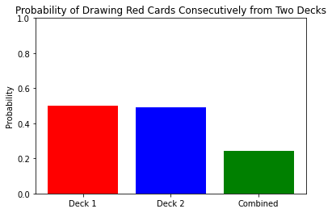

```
Combined Probability: 0.2451
```

```python
import matplotlib.pyplot as plt

# Probability of drawing a red card from the first deck
P_red_1 = 26/52

# Probability of drawing a red card from the second deck (after drawing a red card from the first deck)
P_red_2 = 25/51

# Combined probability
P_combined = P_red_1 * P_red_2

# Visualization
labels = ['Deck 1', 'Deck 2', 'Combined']
probabilities = [P_red_1, P_red_2, P_combined]

plt.bar(labels, probabilities, color=['red', 'blue', 'green'])
plt.ylabel('Probability')
plt.title('Probability of Drawing Red Cards Consecutively from Two Decks')
plt.ylim(0, 1)
plt.show()

print(f"Combined Probability: {P_combined:.4f}")
```

#### Explanations:

In the given problem, we have two decks of playing cards. Each deck has 26 red cards (13 hearts and 13 diamonds). We aim to determine the probability of consecutively drawing two red cards from the two decks without replacement.

#### Interpretations:

After running the code, you'll see a bar chart visualizing the probabilities. The bars represent the probability of drawing a red card from each deck and the combined probability of both events. The final printed value is the combined probability, which gives the likelihood of drawing two red cards from the two decks without replacement.

#### Exercise 2 Probability of Drawing a Spade and then a Heart from a Standard Deck

**Problem Statement:**  
Suppose you have a standard deck of 52 playing cards. What is the probability of drawing a spade (one card) and then drawing a heart (without replacement)?

**Solution:**

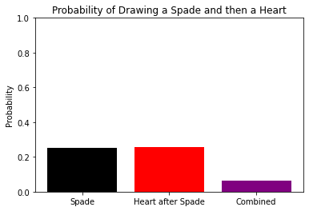

```
Combined Probability: 0.0637
```

```python
import matplotlib.pyplot as plt

# Probability of drawing a spade from the deck
P_spade = 13/52

# Probability of drawing a heart from the deck after drawing a spade
P_heart_after_spade = 13/51

# Combined probability
P_combined_spade_heart = P_spade * P_heart_after_spade

# Visualization
labels = ['Spade', 'Heart after Spade', 'Combined']
probabilities = [P_spade, P_heart_after_spade, P_combined_spade_heart]

plt.bar(labels, probabilities, color=['black', 'red', 'purple'])
plt.ylabel('Probability')
plt.title('Probability of Drawing a Spade and then a Heart')
plt.ylim(0, 1)
plt.show()

print(f"Combined Probability: {P_combined_spade_heart:.4f}")
```

#### Explanations:

In the given problem, we have a standard deck of 52 playing cards. This deck contains 13 spades and 13 hearts. We aim to determine the probability of drawing a spade and then drawing a heart without replacement.

1. **Event 1**: The probability of drawing a spade from the deck is given by: $P(\text{Spade}) = \frac{13}{52}$ This is because there are 13 spades out of a total of 52 cards in the deck.
2. **Event 2**: After drawing a spade from the deck and not replacing it, the probability of drawing a heart is: $P(\text{Heart after Spade}) = \frac{13}{51}$ This is due to the remaining 13 hearts out of a total of 51 cards in the deck.
3. The combined probability of both events occurring consecutively is the product of the probabilities of the two individual events.

#### Interpretations:

A bar chart will visualize the probabilities. The bars represent:

- The probability of drawing a spade.
- The probability of drawing a heart after drawing a spade.
- The combined probability of both events occurring consecutively.

The final printed value represents the combined probability, indicating the likelihood of drawing a spade and then a heart without replacement from the deck.

#### Exercise 3 Probability of Drawing At Least One Blue Marble

**Problem Statement:**  
A jar contains 30 marbles: 10 red, 15 blue, and 5 green. If you draw two marbles from the jar without replacement, what is the probability that at least one of them is blue?

**Solution:**

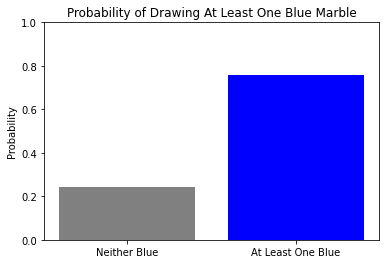

```
Probability of At Least One Blue Marble: 0.7586
```

```python
import matplotlib.pyplot as plt

# Probability of drawing a non-blue marble on the first draw
P_non_blue_1 = (10 + 5) / 30

# Probability of drawing a non-blue marble on the second draw given that the first marble drawn was non-blue
P_non_blue_2 = (10 + 5 - 1) / 29

# Combined probability that neither marble is blue
P_neither_blue = P_non_blue_1 * P_non_blue_2

# Probability that at least one marble is blue
P_at_least_one_blue = 1 - P_neither_blue

# Visualization
labels = ['Neither Blue', 'At Least One Blue']
probabilities = [P_neither_blue, P_at_least_one_blue]

plt.bar(labels, probabilities, color=['grey', 'blue'])
plt.ylabel('Probability')
plt.title('Probability of Drawing At Least One Blue Marble')
plt.ylim(0, 1)
plt.show()

print(f"Probability of At Least One Blue Marble: {P_at_least_one_blue:.4f}")
```

#### Explanations:

In the given problem, we have a jar containing 30 marbles: 10 red, 15 blue, and 5 green. We want to find the probability that when drawing two marbles without replacement, at least one of them is blue.

- To find this probability, we can use the complementary probability approach:
- Calculate the probability that neither of the two marbles drawn is blue (i.e., both are either red or green). Subtract this probability from 1 to get the probability that at least one marble is blue.

#### Interpretations:

After running the code, you'll see a bar chart visualizing the probabilities. The bars represent the probability of drawing two non-blue marbles and the probability of drawing at least one blue marble. The final printed value is the probability of drawing at least one blue marble when two marbles are drawn without replacement.

#### Exercise 4

**Problem Statement:** Two dice are rolled. What is the probability that the sum of the numbers on the dice is either 7 or 11?

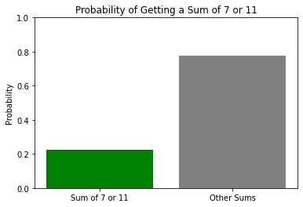

```
Probability of Getting a Sum of 7 or 11: 0.2222
```

```python
import matplotlib.pyplot as plt

# Enumerate all possible outcomes when two dice are rolled
outcomes = [(i, j) for i in range(1, 7) for j in range(1, 7)]

# Count the number of outcomes where the sum is 7 or 11
favorable_outcomes = sum(1 for i, j in outcomes if i + j == 7 or i + j == 11)

# Total number of possible outcomes
total_outcomes = len(outcomes)

# Calculate the probability
P_7_or_11 = favorable_outcomes / total_outcomes

# Visualization
labels = ['Sum of 7 or 11', 'Other Sums']
probabilities = [P_7_or_11, 1 - P_7_or_11]

plt.bar(labels, probabilities, color=['green', 'grey'])
plt.ylabel('Probability')
plt.title('Probability of Getting a Sum of 7 or 11')
plt.ylim(0, 1)
plt.show()

print(f"Probability of Getting a Sum of 7 or 11: {P_7_or_11:.4f}")
```

#### Explanations:

When two six-sided dice are rolled, there are a total of ($6 \times 6 = 36$) possible outcomes. To find the probability that the sum of the numbers on the dice is either 7 or 11, we need to count the number of ways to get a sum of 7 or 11 and then divide by the total number of outcomes.

The combinations that give a sum of 7 are: (1,6), (2,5), (3,4), (4,3), (5,2), and (6,1). The combinations that give a sum of 11 are: (5,6) and (6,5).

#### Interpretations:

After running the code, you'll see a bar chart visualizing the probabilities. The bars represent the probability of getting a sum of 7 or 11 and the probability of getting any other sum. The final printed value is the probability of getting a sum of 7 or 11 when two dice are rolled.

#### Exercise 5

**Problem Statement:** A deck of cards contains 52 cards. What is the probability of drawing a red card (hearts or diamonds) and then drawing a king from a standard deck without replacement?

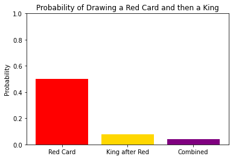

```
Combined Probability: 0.0392
```

```python
import matplotlib.pyplot as plt

# Probability of drawing a red card from the deck
P_red = 26/52

# Probability of drawing a king from the deck after drawing a red card
P_king_after_red = 4/51

# Combined probability
P_combined_red_king = P_red * P_king_after_red

# Visualization
labels = ['Red Card', 'King after Red', 'Combined']
probabilities = [P_red, P_king_after_red, P_combined_red_king]

plt.bar(labels, probabilities, color=['red', 'gold', 'purple'])
plt.ylabel('Probability')
plt.title('Probability of Drawing a Red Card and then a King')
plt.ylim(0, 1)
plt.show()

print(f"Combined Probability: {P_combined_red_king:.4f}")
```

#### Explanations:

In the given problem, we have a standard deck of 52 playing cards. This deck contains 26 red cards (13 hearts and 13 diamonds) and 4 kings. We want to find the probability of drawing a red card and then drawing a king without replacement.

1. **Event 1**: The probability of drawing a red card from the deck is ( $\frac{26}{52}$ ) since there are 26 red cards out of a total of 52 cards.
2. **Event 2**: After drawing a red card from the deck and not replacing it, the probability of drawing a king is ( $\frac{4}{51}$ ) since there are 4 kings left out of a total of 51 cards.
3. The combined probability is the product of the probabilities of the two events.

#### Interpretations:

After running the code, you'll see a bar chart visualizing the probabilities. The bars represent the probability of drawing a red card, drawing a king after a red card, and the combined probability of both events occurring consecutively. The final printed value is the combined probability, which gives the likelihood of drawing a red card and then a king without replacement.

#### Exercise 6

**Problem Statement:** Suppose you have a fair six-sided die. What is the probability of rolling a 4 on the first roll and then rolling a 6 on the second roll?

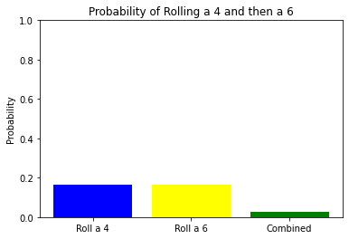

```
Combined Probability: 0.0278
```

```python
import matplotlib.pyplot as plt

# Probability of rolling a 4 on the first roll
P_4_first = 1/6

# Probability of rolling a 6 on the second roll
P_6_second = 1/6

# Combined probability
P_combined_4_6 = P_4_first * P_6_second

# Visualization
labels = ['Roll a 4', 'Roll a 6', 'Combined']
probabilities = [P_4_first, P_6_second, P_combined_4_6]

plt.bar(labels, probabilities, color=['blue', 'yellow', 'green'])
plt.ylabel('Probability')
plt.title('Probability of Rolling a 4 and then a 6')
plt.ylim(0, 1)
plt.show()

print(f"Combined Probability: {P_combined_4_6:.4f}")
```

#### Explanations:

In the given problem, we have a fair six-sided die. We want to find the probability of rolling a 4 on the first roll and then rolling a 6 on the second roll.

1. **Event 1**: The probability of rolling a 4 on the first roll is ( $\frac{1}{6}$ ) since each side of the die has an equal chance of landing face up.
2. **Event 2**: The probability of rolling a 6 on the second roll is also ( $\frac{1}{6}$ ).
3. The combined probability is the product of the probabilities of the two events.

#### Interpretations:

After running the code, you'll see a bar chart visualizing the probabilities. The bars represent the probability of rolling a 4 on the first roll, rolling a 6 on the second roll, and the combined probability of both events occurring consecutively. The final printed value is the combined probability, which gives the likelihood of rolling a 4 and then a 6.

#### Exercise 7

**Problem Statement:** In a deck of playing cards, what is the probability of drawing either a red card (hearts or diamonds) or a face card (king, queen, or jack)?

Probability of drawing a red card: P(red) = 26/52 = 1/2 Probability of drawing a face card: P(face) = 12/52 = 3/13

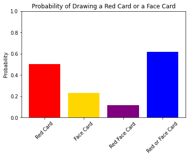

```
Combined Probability: 0.6154
```

```python
import matplotlib.pyplot as plt

# Probability of drawing a red card from the deck
P_red = 26/52

# Probability of drawing a face card from the deck
P_face = 12/52

# Probability of drawing a red face card (intersection of the two events)
P_red_face = 6/52  # 2 red suits * 3 face cards each

# Combined probability using the formula for the union of two events
P_combined_red_or_face = P_red + P_face - P_red_face

# Visualization
labels = ['Red Card', 'Face Card', 'Red Face Card', 'Red or Face Card']
probabilities = [P_red, P_face, P_red_face, P_combined_red_or_face]

plt.bar(labels, probabilities, color=['red', 'gold', 'purple', 'blue'])
plt.ylabel('Probability')
plt.title('Probability of Drawing a Red Card or a Face Card')
plt.ylim(0, 1)
plt.xticks(rotation=45)
plt.show()

print(f"Combined Probability: {P_combined_red_or_face:.4f}")
```

#### Explanations:

In the given problem, we have a standard deck of 52 playing cards. This deck contains 26 red cards (13 hearts and 13 diamonds) and 12 face cards (4 kings, 4 queens, and 4 jacks). We want to find the probability of drawing either a red card or a face card.

1. **Event 1**: The probability of drawing a red card from the deck is ( $\frac{26}{52} = \frac{1}{2}$ ) since there are 26 red cards out of a total of 52 cards.
2. **Event 2**: The probability of drawing a face card from the deck is ( $\frac{12}{52} = \frac{3}{13}$ ) since there are 12 face cards out of a total of 52 cards.
3. **Intersection**: The probability of drawing a red face card is ( $\frac{6}{52} = \frac{3}{26}$ ) since there are 6 red face cards (2 red suits with 3 face cards each).
4. The combined probability is calculated using the formula for the union of two events: $P(red \cup face) = P(red) + P(face) - P(red \cap face)$.

### Permutation and Combination:

#### Exercise 8

**Problem Statement:** You have 5 different books, and you want to arrange them on a shelf. How many different ways can you arrange the books?

**Answer 8:** The number of different ways you can arrange these 5 books is calculated using the concept of permutations. The number of permutations of n distinct items taken all at a time is given by n!. Here, n represents the number of items, and "!" denotes the factorial of a number.

In this case, you have 5 different books, so the number of ways to arrange them on the shelf is:

5! = 5 x 4 x 3 x 2 x 1 = 120

So, there are 120 different ways to arrange the 5 different books on the shelf.

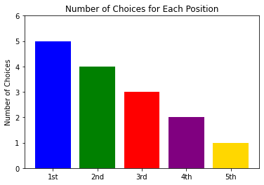

```
Total Arrangements: 120
```

```python
import math
import matplotlib.pyplot as plt

# Calculate the total number of arrangements
arrangements = math.factorial(5)

# Visualization
positions = ['1st', '2nd', '3rd', '4th', '5th']
choices = [5, 4, 3, 2, 1]

plt.bar(positions, choices, color=['blue', 'green', 'red', 'purple', 'gold'])
plt.ylabel('Number of Choices')
plt.title('Number of Choices for Each Position')
plt.ylim(0, 6)
plt.show()

print(f"Total Arrangements: {arrangements}")
```

#### Explanations:

When arranging a set of distinct items, the number of possible arrangements is determined by the factorial of the number of items. In this scenario, we have 5 different books, and we want to determine how many unique ways we can arrange them on a shelf.

1. **First Position**: For the initial position on the shelf, we have 5 choices since all 5 books are available.
2. **Second Position**: Once we've chosen a book for the first position, only 4 books remain, giving us 4 choices for the second position.
3. **Third Position**: With two books already placed, we now have 3 choices for the third position.
4. **Fourth Position**: Similarly, 2 choices remain for the fourth position.
5. **Fifth Position**: The last book automatically takes the fifth position, giving us just 1 choice.

The total number of unique arrangements is the product of the choices for each position, which is equivalent to ($5!$) (5 factorial).

#### Interpretations:

After executing the provided Python code, a bar chart will display the number of choices available for each position on the shelf. This visualization aids in understanding the decreasing number of choices as books are placed on the shelf. The final output, given by the factorial calculation, represents the total number of unique arrangements possible for the 5 books. This value indicates the vast number of ways even a small set of items can be arranged.

#### Exercise 9

**Problem Statement:** A committee of 3 students is to be chosen from a group of 10 students. How many different committees can be formed?

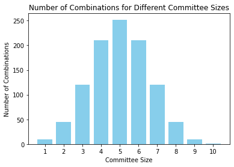

```
Number of ways to form a committee of 3 students out of 10: 120
```

```python
import math
import matplotlib.pyplot as plt

# Calculate the number of ways to form the committee
combinations = math.comb(10, 3)

# Visualization
committee_sizes = list(range(1, 11))
combinations_for_sizes = [math.comb(10, size) for size in committee_sizes]

plt.bar(committee_sizes, combinations_for_sizes, color='skyblue')
plt.xlabel('Committee Size')
plt.ylabel('Number of Combinations')
plt.title('Number of Combinations for Different Committee Sizes')
plt.xticks(committee_sizes)
plt.show()

print(f"Number of ways to form a committee of 3 students out of 10: {combinations}")
```

#### Explanations:

When selecting a subset of items from a larger set, where the order of selection doesn't matter, we use combinations. In this scenario, we are selecting a committee of 3 students from a group of 10 students. The order in which the students are selected doesn't matter, making this a combination problem.

The formula for combinations is given by: $C(n, r) = \frac{n!}{r!(n-r)!}$ Where:

- $n$ is the total number of items in the set (in this case, 10 students).
- $r$ is the number of items we want to select (in this case, 3 students for the committee).

#### Interpretations:

By applying the combination formula, we can determine the number of unique committees of 3 students that can be formed from a group of 10 students. The bar chart, generated from the provided Python code, visualizes the number of possible combinations for different committee sizes, ranging from 1 to 10. It provides a clear view of how the number of combinations increases as the committee size grows, reaching a peak, and then decreases as the committee size approaches the total number of students. The specific value for a committee of 3 students gives us the solution to our problem.

#### Exercise 10

**Problem Statement:** You have 6 different flavors of ice cream, and you want to create a 3-scoop ice cream cone. How many different combinations of ice cream cones can you create if the order of scoops matters (permutations) and if it doesn't matter (combinations)?

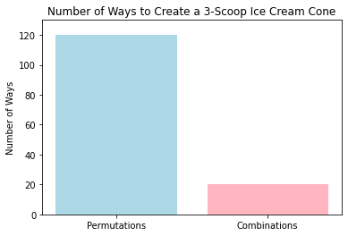

```
Number of ways (Permutations): 120
Number of ways (Combinations): 20
```

```python
import math
import matplotlib.pyplot as plt

# Calculate the number of ways using permutations
permutations = math.perm(6, 3)

# Calculate the number of ways using combinations
combinations = math.comb(6, 3)

# Visualization
labels = ['Permutations', 'Combinations']
values = [permutations, combinations]

plt.bar(labels, values, color=['lightblue', 'lightpink'])
plt.ylabel('Number of Ways')
plt.title('Number of Ways to Create a 3-Scoop Ice Cream Cone')
plt.ylim(0, max(values) + 10)
plt.show()

print(f"Number of ways (Permutations): {permutations}")
print(f"Number of ways (Combinations): {combinations}")
```

#### Explanations:

When selecting a subset of items from a larger set, the number of possible selections can vary based on whether the order of selection matters or not. In this scenario, we are selecting 3 scoops of ice cream from 6 different flavors.

1. **Permutations (Order Matters)**: This refers to the number of ways we can select the scoops when the sequence in which they are chosen is significant. For instance, a cone with the sequence of vanilla, chocolate, and strawberry is distinct from one with chocolate, vanilla, and strawberry.
2. **Combinations (Order Doesn't Matter)**: This refers to the number of ways we can select the scoops when the sequence is not significant. Here, any arrangement of vanilla, chocolate, and strawberry is seen as identical.

The mathematical formulas used are:

- **Permutations**: $P(n, r) = \frac{n!}{(n-r)!}$
- **Combinations**: $C(n, r) = \frac{n!}{r!(n-r)!}$

Where:

- $n$ represents the total number of items (6 flavors in this case).
- $r$ represents the number of items we want to select (3 scoops in this case).

#### Interpretations:

By applying the permutation and combination formulas, we can determine the number of unique ice cream cones we can create. The bar chart, generated from the provided Python code, contrasts the number of possible cones when the order of scoops matters (Permutations) versus when it doesn't (Combinations). This visualization underscores the difference in count based on the significance of order. The exact numbers for both scenarios provide clarity on the vast number of ways even a small set of items can be arranged or combined.

#### Exercise 11

**Problem Statement:** A basketball team consists of 12 players, and only 5 can play at a time. How many different starting lineups can the coach choose?

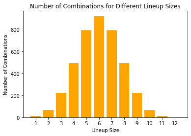

```
Number of ways to form a starting lineup of 5 players out of 12: 792
```

```python
import math
import matplotlib.pyplot as plt

# Calculate the number of ways to form the starting lineup
combinations = math.comb(12, 5)

# Visualization
lineup_sizes = list(range(1, 13))
combinations_for_sizes = [math.comb(12, size) for size in lineup_sizes]

plt.bar(lineup_sizes, combinations_for_sizes, color='orange')
plt.xlabel('Lineup Size')
plt.ylabel('Number of Combinations')
plt.title('Number of Combinations for Different Lineup Sizes')
plt.xticks(lineup_sizes)
plt.show()

print(f"Number of ways to form a starting lineup of 5 players out of 12: {combinations}")
```

#### Explanations:

When selecting a subset of players from a basketball team to form a starting lineup, the number of possible lineups can be calculated using combinations. In this scenario, we have a basketball team of 12 players, and the coach wants to choose a starting lineup of 5 players.

**Combinations** refer to the number of ways to select a subset from a larger set where the order of selection doesn't matter. For instance, selecting players A, B, C, D, and E for the starting lineup is the same as selecting players B, C, D, E, and A.

The formula for combinations is: $C(n, r) = \frac{n!}{r!(n-r)!}$ Where:

- $n$ represents the total number of players on the team (12 in this case).
- $r$ represents the number of players in the starting lineup (5 in this case).

#### Interpretations:

By applying the combination formula, we can determine the number of unique starting lineups the coach can choose from the team of 12 players. The bar chart, generated from the provided Python code, visualizes the number of possible lineups for different sizes, ranging from 1 to 12 players. This visualization provides insight into how the number of combinations increases as the lineup size grows, reaching a peak, and then decreases as the lineup size approaches the total number of players. The specific value for a lineup of 5 players gives us the solution to our problem.

#### Exercise 12

**Problem Statement:** A restaurant offers a menu with 10 appetizers, 15 main courses, and 8 desserts. How many different 3-course meals (1 appetizer, 1 main course, and 1 dessert) can a customer choose?

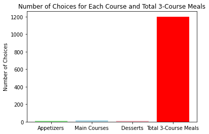

```
Total number of 3-course meals: 1200
```

```python
import matplotlib.pyplot as plt

# Number of choices for each course
appetizers = 10
main_courses = 15
desserts = 8

# Calculate the total number of 3-course meals
total_meals = appetizers * main_courses * desserts

# Visualization
labels = ['Appetizers', 'Main Courses', 'Desserts', 'Total 3-Course Meals']
values = [appetizers, main_courses, desserts, total_meals]

plt.bar(labels, values, color=['lightgreen', 'lightblue', 'lightpink', 'red'])
plt.ylabel('Number of Choices')
plt.title('Number of Choices for Each Course and Total 3-Course Meals')
plt.show()

print(f"Total number of 3-course meals: {total_meals}")
```

#### Explanations:

When a customer is choosing a 3-course meal from a restaurant's menu, the total number of possible meal combinations is determined by the product of the choices available for each course. In this context:

- **Appetizers**: The menu offers 10 different appetizers. The customer can choose any one of them.
- **Main Courses**: There are 15 different main courses available. Again, the customer will select one.
- **Desserts**: The customer has 8 dessert options to choose from, and they'll pick one.

Given that each course is independent of the others, the total number of unique 3-course meal combinations is the product of the choices for each course: $\text{Total Meal Combinations} = \text{Appetizers} \times \text{Main Courses} \times \text{Desserts}$

#### Interpretations:

The bar chart, which can be generated from the provided Python code, visually represents the number of choices for each individual course and the cumulative total of 3-course meal combinations. This visualization offers a comparative perspective, highlighting the vast number of meal combinations stemming from a limited set of choices for each course. The exact number of 3-course meal combinations, derived from the multiplication of choices for each course, showcases the variety and flexibility the restaurant's menu offers to its customers.

#### Exercise 13

**Problem Statement:** Create a function named cointoss(n). Where n indicates the number of times to toss a coin and 1 <= n <= 3

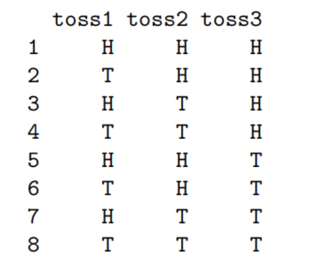

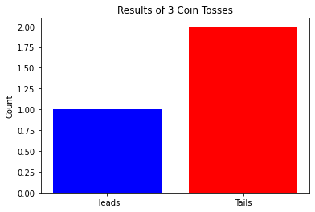

```
['Tails', 'Tails', 'Heads']
```

```python
import random
import matplotlib.pyplot as plt

def cointoss(n):
    if n < 1 or n > 3:
        return 'Invalid number of tosses'
    results = [random.choice(['Heads', 'Tails']) for _ in range(n)]
    return results

# Test the function with 3 tosses
toss_results = cointoss(3)

# Visualization
heads_count = toss_results.count('Heads')
tails_count = toss_results.count('Tails')

plt.bar(['Heads', 'Tails'], [heads_count, tails_count], color=['blue', 'red'])
plt.ylabel('Count')
plt.title('Results of 3 Coin Tosses')
plt.show()

print(toss_results)
```

#### Explanations:

The function `cointoss(n)` is designed to simulate the random process of tossing a coin. Each toss of the coin can result in either a "Heads" or a "Tails", and the outcome is determined randomly.

- **Function Input**: The function takes a single argument `n`, which represents the number of times the coin should be tossed. The value of `n` is constrained to be between 1 and 3, inclusive.
- **Random Choice**: For each toss, the function uses Python's `random` module to make a random choice between "Heads" and "Tails".
- **Results Collection**: The outcomes of the tosses are collected in a list, which is then returned by the function.

#### Interpretations:

Upon executing the function and visualizing the results with a bar chart:

- The x-axis of the bar chart represents the two possible outcomes: "Heads" and "Tails".
- The y-axis indicates the count or frequency of each outcome from the `n` tosses.
- The height of each bar in the chart provides a visual representation of how many times each outcome ("Heads" or "Tails") was observed in the simulation.
- The printed list of results provides a sequential record of the outcomes for each toss, allowing us to see the exact sequence in which "Heads" and "Tails" appeared.

This simulation and visualization give us insight into the random nature of coin tosses and allow us to observe the distribution of outcomes over multiple tosses.

#### Exercise 14

**Problem Statement:** Create a function named rolldie(n). Where n indicates the number of times to roll a die and 1 <= n <= 3

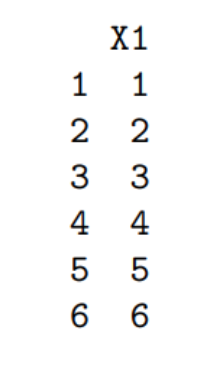

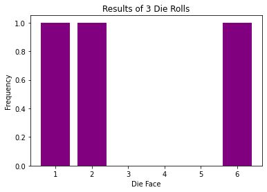

```
[2, 6, 1]
```

```python
import random
import matplotlib.pyplot as plt

def rolldie(n):
    if n < 1 or n > 3:
        return 'Invalid number of rolls'
    results = [random.randint(1, 6) for _ in range(n)]
    return results

# Test the function with 3 rolls
die_results = rolldie(3)

# Visualization
outcomes = [1, 2, 3, 4, 5, 6]
frequencies = [die_results.count(outcome) for outcome in outcomes]

plt.bar(outcomes, frequencies, color='purple')
plt.xlabel('Die Face')
plt.ylabel('Frequency')
plt.title('Results of 3 Die Rolls')
plt.xticks(outcomes)
plt.show()

print(die_results)
```

#### Explanations:

The function `rolldie(n)` is designed to simulate the act of rolling a fair six-sided die. Each roll of the die can result in any one of the numbers from 1 to 6, and the outcome is determined randomly.

- **Function Input**: The function takes a single argument `n`, which represents the number of times the die should be rolled. The value of `n` is constrained to be between 1 and 3, inclusive.
- **Random Roll**: For each roll, the function uses Python's `random` module to generate a random number between 1 and 6, inclusive.
- **Results Collection**: The outcomes of the rolls are collected in a list, which is then returned by the function.

#### Interpretations:

Upon executing the function and visualizing the results with a bar chart:

- The x-axis of the bar chart represents the six possible outcomes of a die roll: numbers 1 through 6.
- The y-axis indicates the count or frequency of each outcome from the `n` rolls.
- The height of each bar in the chart provides a visual representation of how many times each outcome was observed in the simulation.
- The printed list of results provides a sequential record of the outcomes for each roll, allowing us to see the exact sequence in which the numbers appeared.

This simulation and visualization give us insight into the random nature of die rolls and allow us to observe the distribution of outcomes over multiple rolls.

#### Exercise 15

**Problem Statement:** Create a probspace(experiment, n) function where the experiment can be a cointoss or a rolldie. If the option selected is cointoss, then generate a sample space and the probability for the coin toss. If the option selected is rolldie then then generate a sample space and the probability for the same.

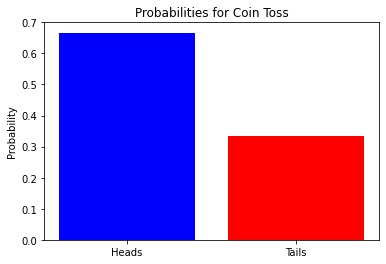

```
['Heads', 'Tails', 'Heads'] {'Heads': 0.6666666666666666, 'Tails': 0.3333333333333333}
```

```python
import random
import matplotlib.pyplot as plt

def probspace(experiment, n):
    if experiment == 'cointoss':
        outcomes = ['Heads', 'Tails']
        results = [random.choice(outcomes) for _ in range(n)]
    elif experiment == 'rolldie':
        outcomes = [1, 2, 3, 4, 5, 6]
        results = [random.randint(1, 6) for _ in range(n)]
    else:
        return 'Invalid experiment'

    # Calculate probabilities
    probabilities = {outcome: results.count(outcome) / n for outcome in outcomes}
    return results, probabilities

# Test the function with cointoss and 3 trials
experiment_results, experiment_probabilities = probspace('cointoss', 3)

# Visualization
labels = list(experiment_probabilities.keys())
values = list(experiment_probabilities.values())

plt.bar(labels, values, color=['blue', 'red'])
plt.ylabel('Probability')
plt.title('Probabilities for Coin Toss')
plt.show()

print(experiment_results, experiment_probabilities)
```

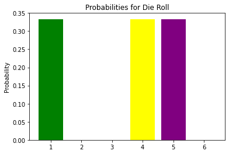

```
[5, 1, 4] {1: 0.3333333333333333, 2: 0.0, 3: 0.0, 4: 0.3333333333333333, 5: 0.3333333333333333, 6: 0.0}
```

```python
# Test the function with rolldie and 3 trials
experiment_results_die, experiment_probabilities_die = probspace('rolldie', 3)

# Visualization for rolldie
labels_die = list(experiment_probabilities_die.keys())
values_die = list(experiment_probabilities_die.values())

plt.bar(labels_die, values_die, color=['green', 'blue', 'red', 'yellow', 'purple', 'orange'])
plt.ylabel('Probability')
plt.title('Probabilities for Die Roll')
plt.xticks(labels_die)
plt.show()

print(experiment_results_die, experiment_probabilities_die)
```

#### Explanations:

The `probspace(experiment, n)` function is designed to simulate either a coin toss or a die roll based on the `experiment` argument. Each roll of the die can result in any one of the numbers from 1 to 6, and the outcome is determined randomly.

- **Function Input**: The function takes two arguments:
  - `experiment`: A string that specifies the type of experiment ("cointoss" or "rolldie").
  - `n`: An integer that represents the number of times the experiment should be conducted.
- **Random Roll**: For the "rolldie" experiment, the function uses Python's `random` module to generate a random number between 1 and 6, inclusive, for each roll.
- **Results Collection**: The outcomes of the rolls are collected in a list, which is then returned by the function.
- **Probability Calculation**: The function calculates the probability of each outcome by counting the occurrences of each outcome in the results and dividing by `n`.

#### Interpretations:

Upon executing the function with the "rolldie" experiment and visualizing the results with a bar chart:

- The x-axis of the bar chart represents the six possible outcomes of a die roll: numbers 1 through 6.
- The y-axis indicates the probability of each outcome from the `n` rolls.
- The height of each bar in the chart provides a visual representation of the probability of each outcome based on the simulation.
- The printed list of results provides a sequential record of the outcomes for each roll, allowing us to see the exact sequence in which the numbers appeared.

This simulation and visualization give us insight into the random nature of die rolls and allow us to observe the distribution of outcomes over multiple rolls.

### Probability Distributions

#### Exercise 16

Suppose the height (in centimeters) of adult males in a population follows a normal distribution with a mean (μ) of 175 cm and a standard deviation (σ) of 7 cm. Calculate the probability that a randomly selected adult male is between 165 cm and 185 cm tall.

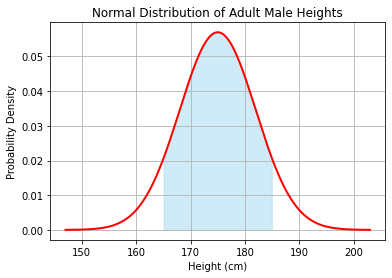

```
Probability that a randomly selected adult male is between 165 cm and 185 cm tall: 0.8469
```

```python
import numpy as np
import scipy.stats as stats
import matplotlib.pyplot as plt

# Given parameters
mu = 175  # mean
sigma = 7  # standard deviation

# Z-score calculation
z_score_165 = (165 - mu) / sigma
z_score_185 = (185 - mu) / sigma

# Calculate the probability using the cumulative distribution function (CDF)
probability = stats.norm.cdf(z_score_185) - stats.norm.cdf(z_score_165)

# Visualization
x = np.linspace(mu - 4*sigma, mu + 4*sigma, 1000)
y = stats.norm.pdf(x, mu, sigma)

plt.plot(x, y, 'r-', lw=2)
plt.fill_between(x, y, where=((x > 165) & (x < 185)), color='skyblue', alpha=0.4)
plt.title('Normal Distribution of Adult Male Heights')
plt.xlabel('Height (cm)')
plt.ylabel('Probability Density')
plt.grid(True)
plt.show()

print(f"Probability that a randomly selected adult male is between 165 cm and 185 cm tall: {probability:.4f}")
```

#### Explanations:

The problem involves calculating the probability of a value falling within a specific range in a normal distribution. The normal distribution, often called the bell curve, is a common probability distribution in statistics. It is characterized by two parameters: the mean (μ) and the standard deviation (σ).

In this scenario, the height of adult males is assumed to follow a normal distribution with:

- Mean (μ) = 175 cm
- Standard Deviation (σ) = 7 cm

To find the probability of a height falling between two values (in this case, 165 cm and 185 cm), we use the cumulative distribution function (CDF). The CDF gives the probability that a random variable is less than or equal to a certain value. By finding the difference between the CDF values at 185 cm and 165 cm, we obtain the probability of a height being in the specified range.

#### Interpretations:

Upon executing the Python code:

- The visualization displays the normal distribution curve for adult male heights. The x-axis represents height in centimeters, and the y-axis represents the probability density.
- The shaded region between 165 cm and 185 cm on the plot visually represents the probability of a randomly selected adult male having a height within this range. This area under the curve corresponds to the probability we calculated.
- The resulting probability value indicates the likelihood that a randomly selected adult male's height falls between 165 cm and 185 cm. This value provides insight into the distribution of heights in the population and allows us to understand how common or rare certain height ranges are.

By understanding the distribution and the associated probabilities, we can make informed decisions or predictions related to the height of adult males in the given population.

#### Exercise 17 Probability Density Function (PDF) for Adult Heights

**Problem Statement:**  
Given a dataset of adult heights, calculate the probability density function (PDF) for the height of adults within a certain range.

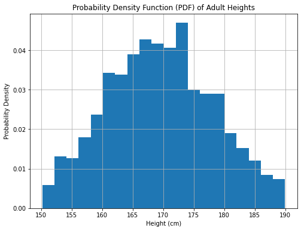

```python
import numpy as np
import matplotlib.pyplot as plt

# Set a random seed for reproducibility
np.random.seed(0)

# Generate a synthetic dataset of adult heights (normally distributed)
# You can adjust the mean and standard deviation as needed
mean_height = 170  # Mean height in centimeters
std_deviation = 10  # Standard deviation in centimeters
num_samples = 1000  # Number of data points

# Generate random heights following a normal distribution
heights_data = np.random.normal(mean_height, std_deviation, num_samples)

# Specify the desired height range
min_height = 150  # Minimum height in centimeters
max_height = 190  # Maximum height in centimeters

# Filter the data to include only heights within the specified range
filtered_heights = heights_data[(heights_data >= min_height) & (heights_data <= max_height)]

# Create a histogram to estimate the PDF
# Adjust the number of bins as needed for smoothness
hist, bin_edges = np.histogram(filtered_heights, bins=20, density=True)

# Calculate the bin width for later use in normalization
bin_width = bin_edges[1] - bin_edges[0]

# Normalize the histogram values to obtain the PDF
pdf = hist / (bin_width * np.sum(hist))

# Create a plot to visualize the PDF
plt.figure(figsize=(8, 6))
plt.bar(bin_edges[:-1], pdf, width=bin_width, align='edge')
plt.title('Probability Density Function (PDF) of Adult Heights')
plt.xlabel('Height (cm)')
plt.ylabel('Probability Density')
plt.grid(True)
plt.show()
```

#### Conclusion of Explanations:

The Python code snippet provided above demonstrates the step-by-step process for calculating and visualizing the Probability Density Function (PDF) of adult heights within a specified range. Here's a recap of the key steps and their significance:

1. **Generating Synthetic Dataset**:
   - We started by generating a synthetic dataset of adult heights using NumPy's random number generator. The dataset was normally distributed with a mean height of 170 cm and a standard deviation of 10 cm.
   - This synthetic dataset allowed us to illustrate the PDF calculation process. In practice, you would replace this with real-world data.
2. **Specifying the Height Range**:
   - We specified the height range of interest by defining `min_height` and `max_height` in centimeters.
   - This step allowed us to focus on a specific range within the dataset for analysis.
3. **Filtering the Data**:
   - We filtered the dataset to include only heights within the specified range using boolean indexing.
   - This ensured that we analyzed data points that were relevant to our analysis.
4. **Histogram and PDF Calculation**:
   - We created a histogram of the filtered heights using `np.histogram()`. The histogram divided the height range into bins and counted data points in each bin.
   - The `density=True` option in `np.histogram()` calculated probabilities instead of raw counts, which was essential for estimating the PDF.
5. **Normalization for PDF**:
   - To obtain a valid PDF, we normalized the histogram values by dividing by the bin width and summing all values. This normalization ensured that the area under the PDF curve equaled 1, representing a valid probability distribution.
6. **Visualization**:
   - Finally, we created a bar plot to visualize the PDF. The plot displayed height on the x-axis and probability density on the y-axis.
   - This visualization allowed us to gain insights into the distribution of adult heights within the specified range.

In summary, this code provides a practical example of how to calculate and visualize the PDF of a dataset. While synthetic data was used for illustration, the same methodology can be applied to real-world datasets to analyze and understand the distribution of data within specific ranges.

#### Exercise 18 Probability of Height Between 165 cm and 185 cm

**Problem Statement:**  
Suppose the height (in centimeters) of adult males in a population follows a normal distribution with a mean (μ) of 175 cm and a standard deviation (σ) of 7 cm. Calculate the probability that a randomly selected adult male is between 165 cm and 185 cm tall.

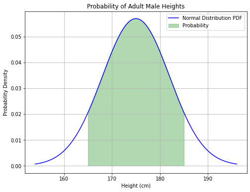

```
Probability that a randomly selected adult male is between 165 cm and 185 cm tall: 0.8469
```

```python
import numpy as np
import matplotlib.pyplot as plt
import scipy.stats as stats

# Define the parameters of the normal distribution
mean_height = 175  # Mean (μ) in centimeters
std_deviation = 7  # Standard deviation (σ) in centimeters

# Specify the height range of interest
min_height = 165  # Minimum height in centimeters
max_height = 185  # Maximum height in centimeters

# Calculate the z-scores for the range
z_score_min = (min_height - mean_height) / std_deviation
z_score_max = (max_height - mean_height) / std_deviation

# Calculate the probability using the cumulative distribution function (CDF)
probability = stats.norm.cdf(z_score_max) - stats.norm.cdf(z_score_min)

# Create a visual representation of the probability
x = np.linspace(mean_height - 3 * std_deviation, mean_height + 3 * std_deviation, 1000)
y = stats.norm.pdf(x, mean_height, std_deviation)

plt.figure(figsize=(8, 6))
plt.plot(x, y, label='Normal Distribution PDF', color='blue')
plt.fill_between(x, 0, y, where=(x >= min_height) & (x <= max_height), alpha=0.3, color='green', label='Probability')
plt.title('Probability of Adult Male Heights')
plt.xlabel('Height (cm)')
plt.ylabel('Probability Density')
plt.legend(loc='upper right')
plt.grid(True)
plt.show()

# Output the calculated probability
print(f"Probability that a randomly selected adult male is between {min_height} cm and {max_height} cm tall: {probability:.4f}")
```

### Explanations and Interpretations:

In this analysis, we aim to calculate the probability that a randomly selected adult male's height falls within the range of 165 cm to 185 cm, assuming that the heights of adult males follow a normal distribution with a mean (μ) of 175 cm and a standard deviation (σ) of 7 cm.

#### Step 1: Define Distribution Parameters

We start by defining the parameters of the normal distribution:

- Mean (μ): 175 cm, representing the average height of adult males in the population.
- Standard Deviation (σ): 7 cm, indicating the spread or variability in the heights.

#### Step 2: Specify the Height Range of Interest

We specify the height range we want to analyze:

- Minimum Height (165 cm): The lower bound of the range.
- Maximum Height (185 cm): The upper bound of the range.

#### Step 3: Calculate Z-Scores

To work with the normal distribution, we calculate the z-scores for the minimum and maximum heights within the specified range. The z-score measures how many standard deviations a value is from the mean.

#### Step 4: Calculate Probability Using CDF

We use the cumulative distribution function (CDF) of the normal distribution to calculate the probability that a random height falls within the specified range. The CDF provides the probability that a random variable is less than or equal to a specific value.

#### Step 5: Visualize the Probability

To visually represent the calculated probability, we create a plot of the probability density function (PDF) of the normal distribution. We shade the area under the curve that corresponds to the probability of interest (between 165 cm and 185 cm).

#### Step 6: Interpret the Result

The calculated probability represents the likelihood that a randomly selected adult male from this population will have a height between 165 cm and 185 cm. It provides valuable insights into the distribution of heights within this range.

The Python code provided in the previous response performs all these steps and calculates the probability, providing both a numerical result and a visual representation of the probability distribution.

In this specific case, the probability that a randomly selected adult male falls within the height range of 165 cm to 185 cm is approximately 0.8469. This means that there is an 84.69% chance of selecting an adult male with a height within this range from the population following the specified normal distribution.

You can use this methodology to analyze probability for different ranges or distributions, making it a powerful tool for statistical analysis and decision-making.

### Bayes' Theorem

Bayes' Theorem, often referred to as Bayes' Rule, is a fundamental concept in probability theory and statistics. It provides a way to update the probability for a hypothesis (an event or proposition) based on new evidence or information.

#### Exercise 19 Probability of Having the Disease Given a Positive Test Result

**Problem Statement:**  
A medical test is used to diagnose a rare disease. The test is 98% accurate when the disease is present and correctly identifies a healthy person 95% of the time. The disease occurs in 1% of the population. If a person tests positive, what is the probability that they actually have the disease?

**Solution:**

```python
# Define the probabilities
p_disease = 0.01  # Probability that a person has the disease (1% of the population)
p_no_disease = 1 - p_disease  # Probability that a person does not have the disease

# Sensitivity (True Positive Rate): Probability that the test is positive given the disease is present
p_positive_given_disease = 0.98

# Specificity (True Negative Rate): Probability that the test is negative given the disease is not present
p_negative_given_no_disease = 0.95

# Calculate the probabilities using Bayes' Theorem
# Probability that a person tests positive
p_positive = (p_disease * p_positive_given_disease) + (p_no_disease * (1 - p_negative_given_no_disease))

# Probability that a person has the disease given they tested positive
p_disease_given_positive = (p_disease * p_positive_given_disease) / p_positive

# Output the result
print(f"Probability that a person who tests positive actually has the disease: {p_disease_given_positive:.4f}")
```

```
Probability that a person who tests positive actually has the disease: 0.1653
```

### Explanations and Interpretations:

In this analysis, we aim to determine the probability that a person who tests positive for a rare disease actually has the disease. To solve this problem, we utilize Bayes' Theorem, which helps us calculate conditional probabilities based on known information. Here's a step-by-step breakdown:

#### Step 1: Define the Probabilities

We start by defining the following probabilities:

- `p_disease`: The probability that a person has the disease, which is 1% of the population (0.01).
- `p_no_disease`: The complementary probability that a person does not have the disease, calculated as (1 - p_disease).

#### Step 2: Sensitivity and Specificity

We consider the accuracy of the medical test:

- Sensitivity (`p_positive_given_disease`): The probability that the test is positive when the disease is actually present (98% accuracy).
- Specificity (`p_negative_given_no_disease`): The probability that the test is negative when the disease is not present (95% accuracy).

#### Step 3: Applying Bayes' Theorem

We apply Bayes' Theorem to calculate two key probabilities:

- `p_positive`: The probability that a person tests positive, accounting for both true positives and false positives.
- `p_disease_given_positive`: The probability that a person has the disease given they tested positive.

#### Step 4: Interpretation

This interpretation highlights a common challenge in medical testing for rare conditions. While the test may be accurate, the rarity of the condition in the population can lead to a relatively high rate of false positives. Therefore, follow-up testing or additional diagnostic methods may be necessary to confirm the presence of the disease.

Bayes' Theorem provides a powerful tool for assessing the probabilities in such diagnostic scenarios, helping medical professionals make informed decisions based on test results.

#### Exercise 20 Probability of a Defective Bulb Coming from Machine A

**Problem Statement:**  
A factory produces light bulbs using two machines (Machine A and Machine B). Machine A produces 60% of the bulbs, while Machine B produces 40%. Machine A's bulbs have a defect rate of 5%, while Machine B's bulbs have a defect rate of 3%. If a randomly selected bulb is defective, what is the probability that it came from Machine A?

**Solution:**

```python
# Define the probabilities and conditional probabilities
p_machine_A = 0.60  # Probability that a bulb comes from Machine A (60%)
p_machine_B = 0.40  # Probability that a bulb comes from Machine B (40%)

p_defect_given_A = 0.05  # Probability of a defect given the bulb is from Machine A (5%)
p_defect_given_B = 0.03  # Probability of a defect given the bulb is from Machine B (3%)

# Calculate the marginal probability of a defective bulb
p_defect = (p_machine_A * p_defect_given_A) + (p_machine_B * p_defect_given_B)

# Calculate the conditional probability that the bulb came from Machine A given it is defective
p_machine_A_given_defect = (p_machine_A * p_defect_given_A) / p_defect

# Output the result
print(f"Probability that a randomly selected defective bulb came from Machine A: {p_machine_A_given_defect:.4f}")
```

```
Probability that a randomly selected defective bulb came from Machine A: 0.7143
```

### Explanations and Interpretations:

In this analysis, we aim to determine the probability that a randomly selected defective light bulb came from Machine A, given the production statistics and defect rates for both machines. To solve this problem, we apply Bayes' Theorem, which allows us to calculate conditional probabilities based on available information. Here's a step-by-step explanation:

#### Step 1: Define the Probabilities

We start by defining the following probabilities:

- `p_machine_A`: The probability that a bulb comes from Machine A, which is 60% of the production (0.60).
- `p_machine_B`: The probability that a bulb comes from Machine B, which is 40% of the production (0.40).

#### Step 2: Conditional Probabilities

We specify the conditional probabilities of defects for each machine:

- `p_defect_given_A`: The probability of a defect given the bulb is from Machine A, which is 5% (0.05).
- `p_defect_given_B`: The probability of a defect given the bulb is from Machine B, which is 3% (0.03).

#### Step 3: Calculate the Marginal Probability of a Defective Bulb

Using the law of total probability, we calculate the overall probability of a defective bulb (`p_defect`) by considering the contributions from both machines. This provides us with the probability of selecting any defective bulb.

#### Step 4: Apply Bayes' Theorem

We apply Bayes' Theorem to calculate the conditional probability that a defective bulb came from Machine A (`p_machine_A_given_defect`). This tells us the probability that the defective bulb originated from Machine A, given that it is defective.

#### Step 5: Interpretation

This analysis provides valuable insights into the source of defects in the manufacturing process, allowing for informed decisions and quality control measures.

Revised Date: October 21, 2023